# Zindi Challenge - Credit Scoring

link to challenge: http://zindi.africa/competitions/sbtic-xente-credit-scoring-challenge

Outline:

1. Pre-processing
2. Exploratory Data Analysis
3. Training and Validation
4. Final Prediction

```r
## load packages & reading in data
library(tidyverse)
library(tidytuesdayR)
library(scales)
library(lubridate)
library(stringr)
library(ISLR2)
theme_set(theme_light())
```

# Pre-processing (Training data)

```r
# Read in the training data

direc = "C:/Users/Khwezi/Documents/Docu/Zindi challenges/Credit scores/data/"

fname = "Train.csv"

fpath = paste0(direc, fname)

train = read.csv(fpath, sep = ",")
```

# Selecting features (train data)

```r
# Selecting relevant features

naive_train = train %>%
  select(CustomerId, Value, ProductId, ThirdPartyId,
         BatchId, IssuedDateLoan, InvestorId, TransactionStartTime,
         TransactionStatus, LoanId, LoanApplicationId, IsDefaulted)

naive_train %>% head()
```

|  | CustomerId | Value | ProductId | ThirdPartyId | BatchId | IssuedDateLoan | InvestorId | TransactionStartTime | TransactionStatus | LoanId | LoanApplicationId | IsDefaulted |
| --- | --- | --- | --- | --- | --- | --- | --- | --- | --- | --- | --- | --- |
| 1 | CustomerId_27 | 550 | ProductId_7 | NA | BatchId_641 | NA | NA | 2018-09-21 12:17:39 | 0 | NA | NA | NA |
| 2 | CustomerId_27 | 550 | ProductId_7 | NA | BatchId_820 | NA | NA | 2018-09-25 09:20:29 | 0 | NA | NA | NA |
| 3 | CustomerId_27 | 550 | ProductId_7 | NA | BatchId_210 | NA | NA | 2018-09-25 10:33:31 | 0 | NA | NA | NA |
| 4 | CustomerId_27 | 1000 | ProductId_7 | NA | BatchId_876 | NA | NA | 2018-09-27 10:26:41 | 0 | NA | NA | NA |
| 5 | CustomerId_27 | 500 | ProductId_7 | NA | BatchId_1362 | NA | NA | 2018-09-27 12:44:21 | 0 | NA | NA | NA |
| 6 | CustomerId_27 | 500 | ProductId_7 | NA | BatchId_357 | NA | NA | 2018-09-28 12:40:48 | 0 | NA | NA | NA |

# Dealing with dates (train data)

```r
# Dealing with the dates
naive_train$IssuedDateLoan = naive_train$IssuedDateLoan %>% as_datetime()

naive_train$TransactionStartTime = naive_train$TransactionStartTime %>%
  as_datetime()

# Extracting issue dates and forming new columns
naive_train$IssueDay = naive_train$IssuedDateLoan %>% day()

naive_train$IssueMonth = naive_train$IssuedDateLoan %>% month()

naive_train$IssueYear = naive_train$IssuedDateLoan %>% year()

naive_train = naive_train[-6] # removing IssuedDateLoan feature

naive_train[,c(12,13,14)] %>% na.omit() %>% head()
```

|  | IssueDay | IssueMonth | IssueYear |
| --- | --- | --- | --- |
| 10 | 18 | 10 | 2018 |
| 11 | 18 | 10 | 2018 |
| 12 | 18 | 10 | 2018 |
| 14 | 19 | 10 | 2018 |
| 15 | 19 | 10 | 2018 |
| 16 | 22 | 10 | 2018 |

```r
#Extracting transaction dates and forming new columns
naive_train$TransactionDay = naive_train$TransactionStartTime %>% day()

naive_train$TransactionMonth = naive_train$TransactionStartTime %>% month()

naive_train$TransactionYear = naive_train$TransactionStartTime %>% year()

naive_train[,c(15,16,17)] %>% na.omit() %>% head()
```

|  | TransactionDay | TransactionMonth | TransactionYear |
| --- | --- | --- | --- |
| 1 | 21 | 9 | 2018 |
| 2 | 25 | 9 | 2018 |
| 3 | 25 | 9 | 2018 |
| 4 | 27 | 9 | 2018 |
| 5 | 27 | 9 | 2018 |
| 6 | 28 | 9 | 2018 |

# Dealing with the NAs (train data)

One could probably find a smarter way of dealing with the NAs and possibly include dummy variables to indicate whether or not a given customer has even requested a loan, in order to give the model more information to work off of

```r
na_process = na.omit(naive_train)

na_process %>% head()
```

|  | CustomerId | Value | ProductId | ThirdPartyId | BatchId | InvestorId | TransactionStartTime | TransactionStatus | LoanId | LoanApplicationId | IsDefaulted | IssueDay | IssueMonth | IssueYear | TransactionDay | TransactionMonth | TransactionYear |
| --- | --- | --- | --- | --- | --- | --- | --- | --- | --- | --- | --- | --- | --- | --- | --- | --- | --- |
| 16 | CustomerId_233 | 5000 | ProductId_7 | ThirdPartyId_1010 | BatchId_775 | InvestorId_3 | 2018-10-22 16:04:25 | 1 | LoanId_317 | LoanApplicationId_1629 | 0 | 22 | 10 | 2018 | 22 | 10 | 2018 |
| 18 | CustomerId_305 | 500 | ProductId_7 | ThirdPartyId_1566 | BatchId_2016 | InvestorId_2 | 2018-10-23 13:12:23 | 1 | LoanId_1619 | LoanApplicationId_136 | 0 | 23 | 10 | 2018 | 23 | 10 | 2018 |
| 19 | CustomerId_27 | 1000 | ProductId_7 | ThirdPartyId_1265 | BatchId_1675 | InvestorId_2 | 2018-10-23 15:20:58 | 1 | LoanId_1438 | LoanApplicationId_1171 | 0 | 23 | 10 | 2018 | 23 | 10 | 2018 |
| 20 | CustomerId_27 | 500 | ProductId_7 | ThirdPartyId_1962 | BatchId_2449 | InvestorId_2 | 2018-10-23 15:31:27 | 1 | LoanId_1304 | LoanApplicationId_702 | 0 | 24 | 10 | 2018 | 23 | 10 | 2018 |
| 21 | CustomerId_27 | 500 | ProductId_4 | ThirdPartyId_2008 | BatchId_1564 | InvestorId_2 | 2018-10-24 06:56:02 | 1 | LoanId_1436 | LoanApplicationId_508 | 0 | 24 | 10 | 2018 | 24 | 10 | 2018 |
| 23 | CustomerId_233 | 500 | ProductId_7 | ThirdPartyId_679 | BatchId_1854 | InvestorId_2 | 2018-10-24 11:37:16 | 1 | LoanId_1435 | LoanApplicationId_1546 | 0 | 24 | 10 | 2018 | 24 | 10 | 2018 |

# Encoding the feature ids into numeric values (train data)

```r
# Encoding the customer_ids into numeric values
na_process$CustomerId = str_extract(na_process$CustomerId, "\\d+")

na_process$CustomerId = as.numeric(na_process$CustomerId)

# Encoding product_ids into numeric values
na_process$ProductId = str_extract(na_process$ProductId, "\\d+")
na_process$ProductId = as.numeric(na_process$ProductId)

# Encoding third_party_ids into numeric values
na_process$ThirdPartyId = str_extract(na_process$ThirdPartyId, "\\d+")
na_process$ThirdPartyId = as.numeric(na_process$ThirdPartyId)

# Encoding batch_ids into numeric values
na_process$BatchId = str_extract(na_process$BatchId, "\\d+")
na_process$BatchId = as.numeric(na_process$BatchId)

# Encoding investor_ids into numeric values
na_process$InvestorId = str_extract(na_process$InvestorId, "\\d+")
na_process$InvestorId = as.numeric(na_process$InvestorId)

# Encoding loan_ids into numeric values
na_process$LoanId = str_extract(na_process$LoanId, "\\d+")
na_process$LoanId = as.numeric(na_process$LoanId)

# Encoding loan_application_ids into numeric values
na_process$LoanApplicationId = str_extract(na_process$LoanApplicationId, "\\d+")
na_process$LoanApplicationId = as.numeric(na_process$LoanApplicationId)

na_process[,c(1,3,4,5,6,9,10)] %>% head()
```

|  | CustomerId | ProductId | ThirdPartyId | BatchId | InvestorId | LoanId | LoanApplicationId |
| --- | --- | --- | --- | --- | --- | --- | --- |
| 16 | 233 | 7 | 1010 | 775 | 3 | 317 | 1629 |
| 18 | 305 | 7 | 1566 | 2016 | 2 | 1619 | 136 |
| 19 | 27 | 7 | 1265 | 1675 | 2 | 1438 | 1171 |
| 20 | 27 | 7 | 1962 | 2449 | 2 | 1304 | 702 |
| 21 | 27 | 4 | 2008 | 1564 | 2 | 1436 | 508 |
| 23 | 233 | 7 | 679 | 1854 | 2 | 1435 | 1546 |

# Remove the transaction status column

```r
na_process$TransactionStatus %>% sum()
```

```
## [1] 1481
```

```r
na_process = na_process[-c(7,8)] # removing trans. status and trans. start date
```

# Normalizing the features

Having a brief look at our dataframe and we notice that the features are on different scales (ie. some features have larger values than others) and this may result in features with larger values over-powering those with smaller values (they might end up having a larger impact on the dependent variable). In order to level out or ensure that each feature contributes proportionally to the dependent variable, the features must be normalized (transformed in such a way that the values are on a similar scale).

```r
scale_process = na_process[-9] %>% scale()

scale_df = scale_process %>% as.data.frame()

scale_df$IsDefaulted = na_process$IsDefaulted

scale_df = scale_df[-c(11,14)] # remove transactionyear and issueyear

scale_df %>% head() # the training data
```

|  | CustomerId | Value | ProductId | ThirdPartyId | BatchId | InvestorId | LoanId | LoanApplicationId | IssueDay | IssueMonth | TransactionDay | TransactionMonth | IsDefaulted |
| --- | --- | --- | --- | --- | --- | --- | --- | --- | --- | --- | --- | --- | --- |
| 16 | -0.2383147 | -0.2816344 | -0.1042037 | -0.05154411 | -0.7039320 | 3.819611 | -1.009620 | 1.6892514 | 0.6776541 | 1.214249 | 0.6777739 | 1.214249 | 0 |
| 18 | 0.3125627 | -0.3085170 | -0.1042037 | 0.88865201 | 0.9144474 | 1.599500 | 1.743715 | -1.4752048 | 0.7903555 | 1.214249 | 0.7904826 | 1.214249 | 0 |
| 19 | -1.8144360 | -0.3055300 | -0.1042037 | 0.37966094 | 0.4697517 | 1.599500 | 1.360955 | 0.7185073 | 0.7903555 | 1.214249 | 0.7904826 | 1.214249 | 0 |
| 20 | -1.8144360 | -0.3085170 | -0.1042037 | 1.55828809 | 1.4791197 | 1.599500 | 1.077586 | -0.2755516 | 0.9030569 | 1.214249 | 0.7904826 | 1.214249 | 0 |
| 21 | -1.8144360 | -0.3085170 | -0.6412998 | 1.63607409 | 0.3249974 | 1.599500 | 1.356726 | -0.6867401 | 0.9030569 | 1.214249 | 0.9031912 | 1.214249 | 0 |
| 23 | -0.2383147 | -0.3085170 | -0.1042037 | -0.61126517 | 0.7031844 | 1.599500 | 1.354611 | 1.5133305 | 0.9030569 | 1.214249 | 0.9031912 | 1.214249 | 0 |

# Exploratory Data Analysis

In our training sample, what proportion of customers defaulted?

```r
# In our training sample, what proportion of customers defaulted
na_process %>% select(IsDefaulted) %>%
  summarize(Default_rate =
              sum(na_process$IsDefaulted)/length(na_process$IsDefaulted),
            Non_defult_rate =
              1-sum(na_process$IsDefaulted)/length(na_process$IsDefaulted))
```

| Default_rate | Non_defult_rate |
| --- | --- |
| 0.1188386 | 0.8811614 |

How many defaulted?

```r
na_process %>% count(IsDefaulted)
```

| IsDefaulted | n |
| --- | --- |
| 0 | 1305 |
| 1 | 176 |

How many unique customers are there in our sample? And how many loans have each taken out?

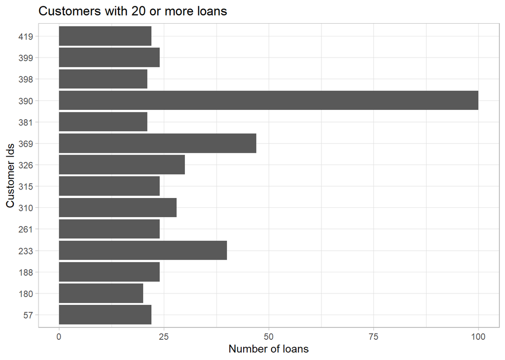

```r
# How many unique customers are there in our sample and how many loans have they each taken out
un_loans = na_process %>% count(CustomerId)

ordered_loans = un_loans %>% arrange(desc(n))

colnames(ordered_loans) = c("CustomerId", "Num_loans")

ordered_loans %>% filter(Num_loans >= 20) %>%ggplot(aes(x = Num_loans, y = as.factor(CustomerId))) + geom_col() +
  xlab("Number of loans") + ylab("Customer Ids") +
  ggtitle("Customers with 20 or more loans")
```

5-number summary of number of loans taken out by each customer:

```r
un_loans$n %>% summary()
```

```
##    Min. 1st Qu.  Median    Mean 3rd Qu.    Max.
##   1.000   1.000   3.000   6.223   7.000 100.000
```

How many unique products did the customers in our sample purchase?

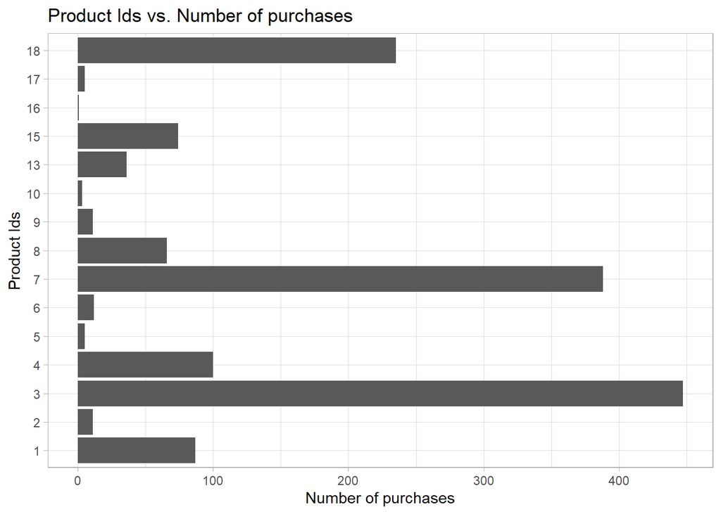

```r
# How many unique products did the customers in our sample purchase
un_products = na_process %>% count(ProductId)

ordered_products = un_products %>% arrange(desc(n))

colnames(ordered_products) = c("ProductId", "Num_purchases")

ordered_products %>% ggplot(aes( x = Num_purchases, y = as.factor(ProductId))) + geom_col() +
  xlab("Number of purchases") + ylab("Product Ids") +
  ggtitle("Product Ids vs. Number of purchases")
```

How many third party ids are there in our sample?

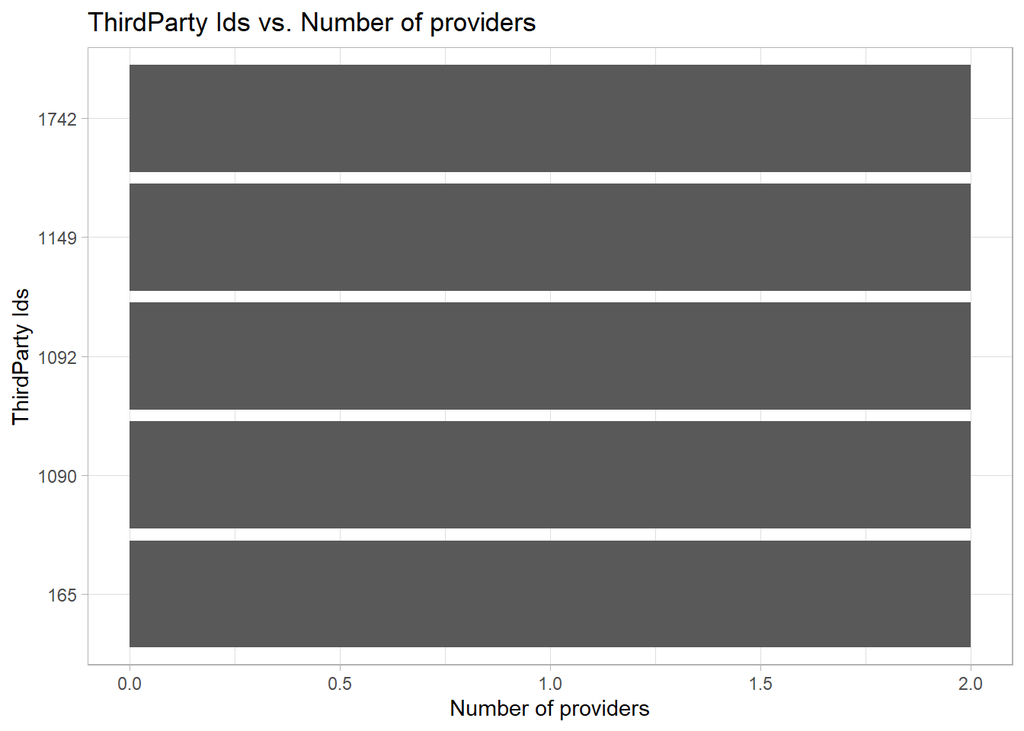

```r
# How many third party ids are there in our sample
un_third = na_process %>% count(ThirdPartyId)

ordered_thirds = un_third %>% filter(n > 1) %>% arrange(desc(n))

colnames(ordered_thirds) = c("ThirdPartyId", "Num_providers")

ordered_thirds %>% ggplot(aes( x = Num_providers, y = as.factor(ThirdPartyId))) + geom_col() +
  xlab("Number of providers") + ylab("ThirdParty Ids") +
  ggtitle("ThirdParty Ids vs. Number of providers")
```

How many unique batch ids are there in our sample?

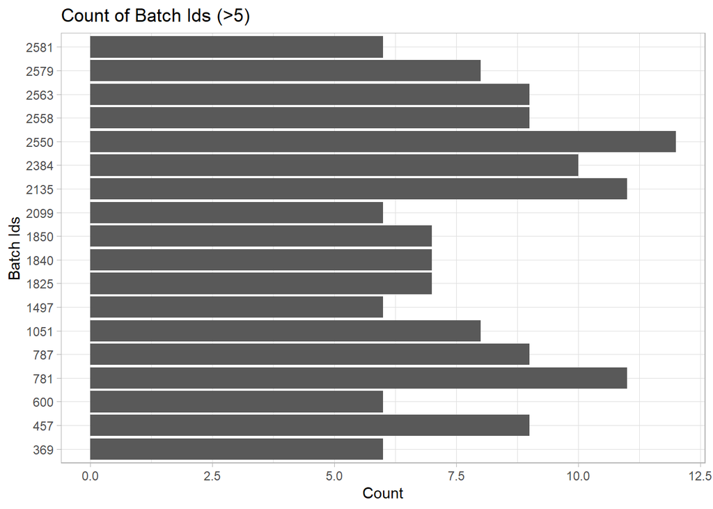

```r
# How many unique batch ids are there in our sample
un_batch = na_process %>% count(BatchId)

ordered_batch = un_batch %>% filter(n > 5) %>% arrange(desc(n))

colnames(ordered_batch) = c("BatchId", "Number")

ordered_batch %>% ggplot(aes(x = Number, y = as.factor(BatchId))) + geom_col() +
  ylab("Batch Ids") + xlab("Count") + ggtitle("Count of Batch Ids (>5)")
```

How many investors are there?

```r
na_process %>% count(InvestorId)
```

| InvestorId | n |
| --- | --- |
| 1 | 1068 |
| 2 | 412 |
| 3 | 1 |

The loan ids and their counts

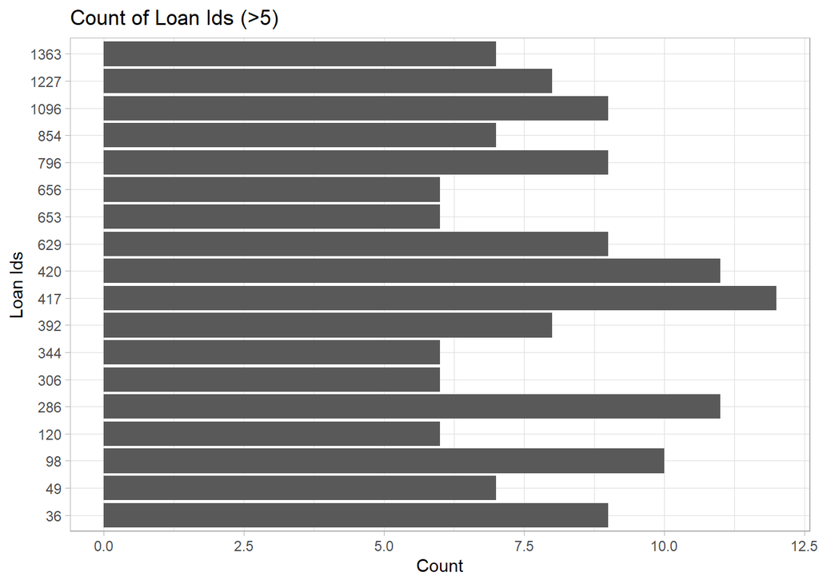

```r
loan_count = na_process %>% count(LoanId)

order_count = loan_count %>% filter(n > 5) %>% arrange(desc(n))

colnames(order_count) = c("LoanId", "Count")

order_count %>% ggplot(aes(x = Count, y = as.factor(LoanId))) + geom_col() +
  ylab("Loan Ids") + ggtitle("Count of Loan Ids (>5)")
```

5-Number summary:

```r
order_count$Count %>% summary()
```

```
##    Min. 1st Qu.  Median    Mean 3rd Qu.    Max.
##   6.000   6.250   8.000   8.167   9.000  12.000
```

The loan applications and their counts

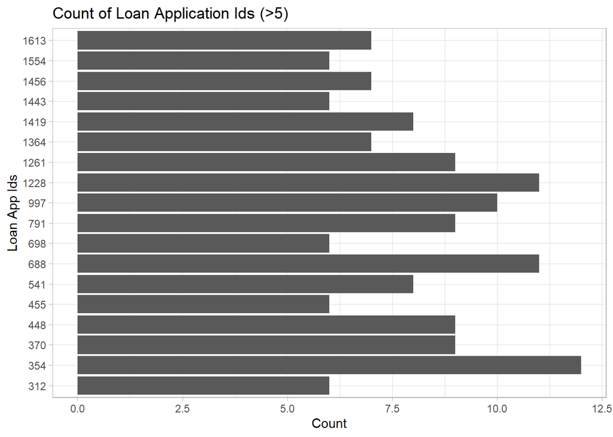

```r
# The loan applications and their counts
loan_app_id = na_process %>% count(LoanApplicationId)

order_loan_app = loan_app_id %>% filter(n > 5) %>% arrange(desc(n))

colnames(order_loan_app) = c("Loan_App_Ids", "Count")

order_loan_app %>% ggplot(aes(x = Count, y = as.factor(Loan_App_Ids))) + geom_col() +
  ylab("Loan App Ids") + ggtitle("Count of Loan Application Ids (>5)")
```

5-Number summary loan application count:

```r
order_loan_app$Count %>% summary()
```

```
##    Min. 1st Qu.  Median    Mean 3rd Qu.    Max.
##   6.000   6.250   8.000   8.167   9.000  12.000
```

On which days are loans issued most?

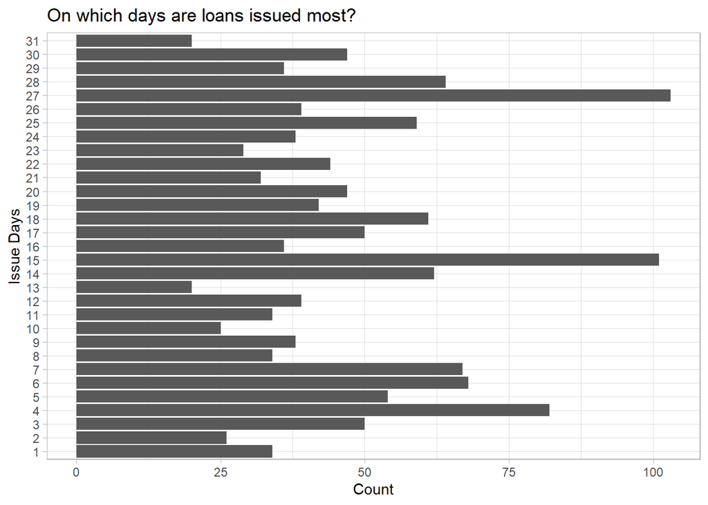

```r
na_process %>% count(IssueDay) %>% ggplot(aes(x = n, y = as.factor(IssueDay))) + geom_col() +
  ylab("Issue Days") + xlab("Count") + ggtitle("On which days are loans issued most?")
```

In which months are loans issued most?

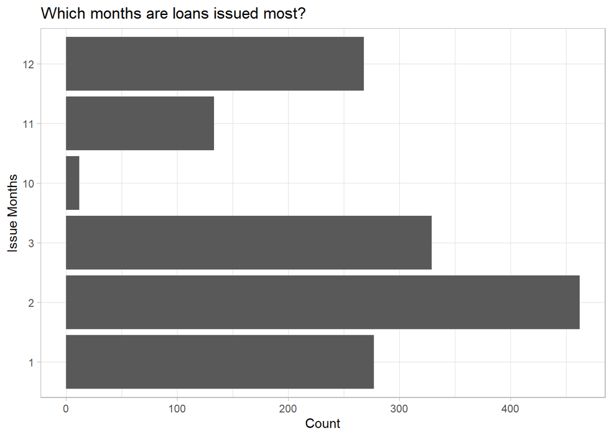

```r
na_process %>% count(IssueMonth) %>% ggplot(aes(x = n, y = as.factor(IssueMonth))) + geom_col() +
  ylab("Issue Months") + xlab("Count") + ggtitle("Which months are loans issued most?")
```

On which days do most transactions occur?

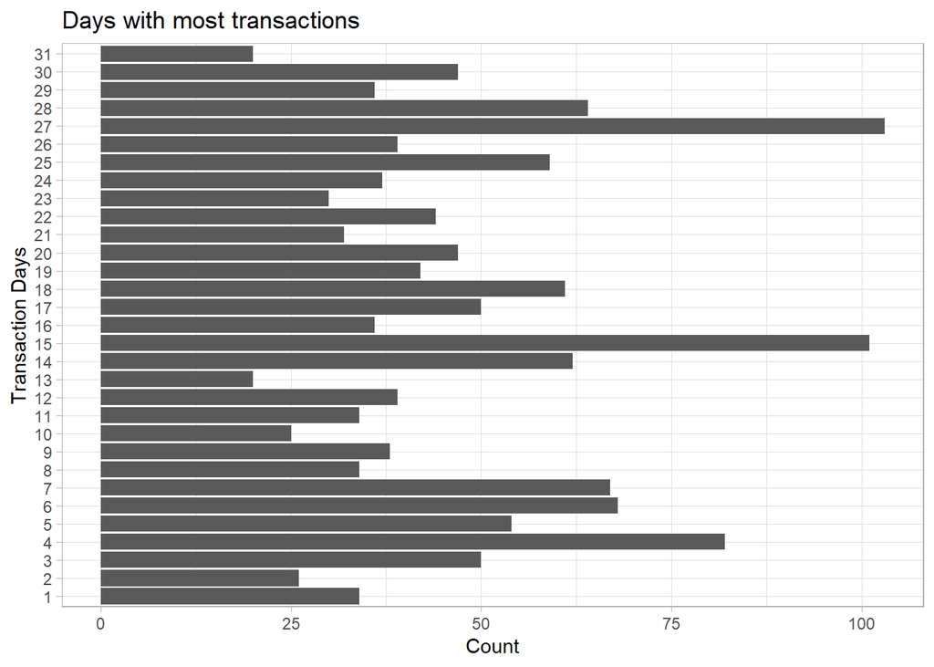

```r
na_process %>% count(TransactionDay) %>% ggplot(aes(x = n, y = as.factor(TransactionDay))) + geom_col() +
  ylab("Transaction Days") + xlab("Count") + ggtitle("Days with most transactions")
```

In which months do most transactions occur?

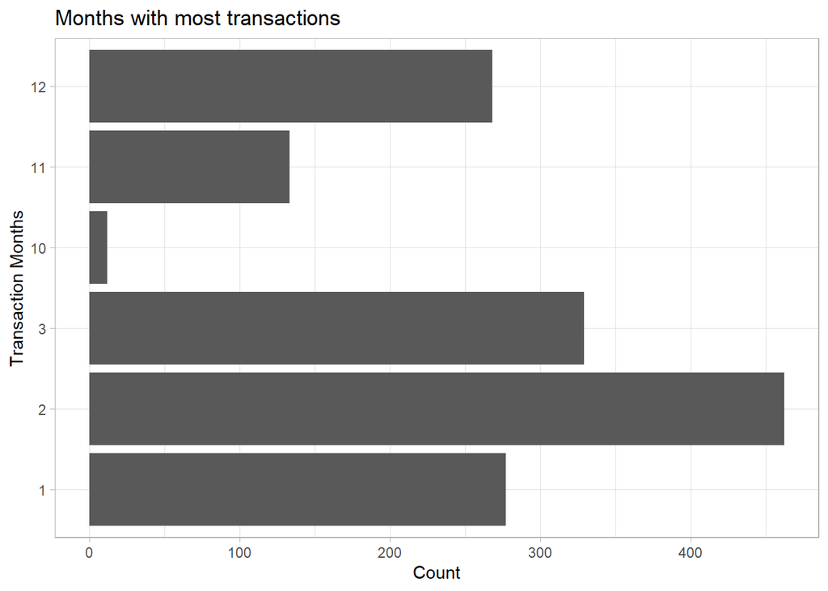

```r
na_process %>% count(TransactionMonth) %>% ggplot(aes(x = n, y = as.factor(TransactionMonth))) + geom_col() +
  ylab("Transaction Months") + xlab("Count") + ggtitle("Months with most transactions")
```

Exploring the loan amounts

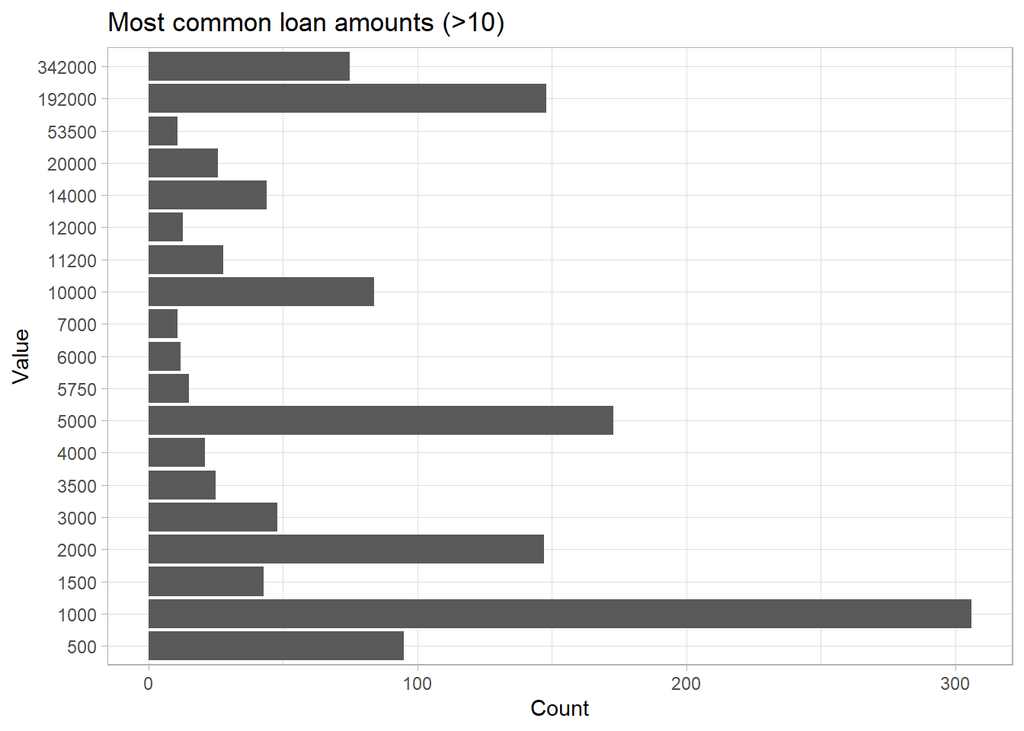

```r
un_amounts = na_process %>% count(Value)

order_amounts = un_amounts %>% filter(n > 10) %>% arrange(desc(n))

order_amounts %>% ggplot(aes(x = n, y = as.factor(Value))) + geom_col() +
  ylab("Value") + xlab("Count") + ggtitle("Most common loan amounts (>10)")
```

Outlier detection (excluding outliers)

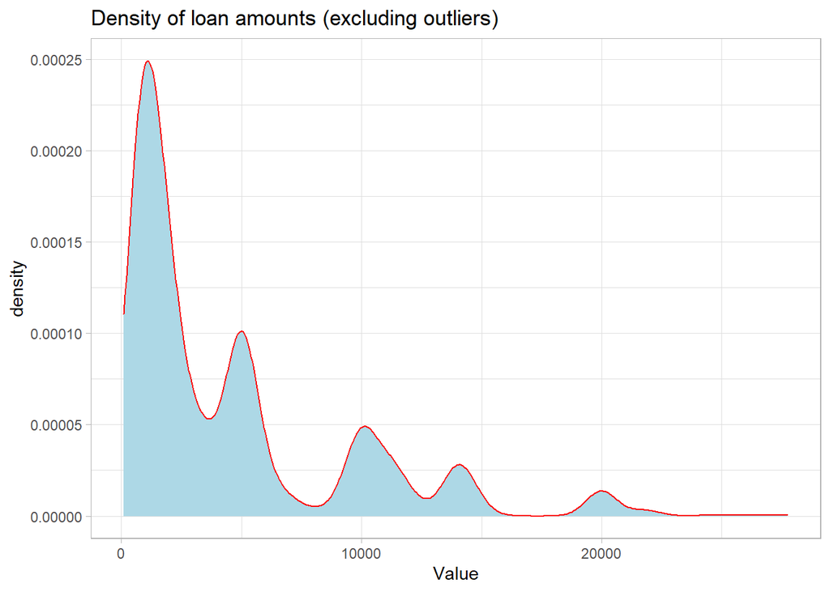

```r
x_iqr = IQR(na_process$Value)

amount_summary = na_process$Value %>% summary()

l_outlier = amount_summary[2] - 1.5*x_iqr

u_outlier = amount_summary[5] + 1.5*x_iqr


na_process %>% filter(Value <= u_outlier) %>% ggplot(aes(Value)) + geom_density(fill = "lightblue", col = "red") +
  xlab("Value") + ggtitle("Density of loan amounts (excluding outliers)")
```

Outlier detection (only outliers)

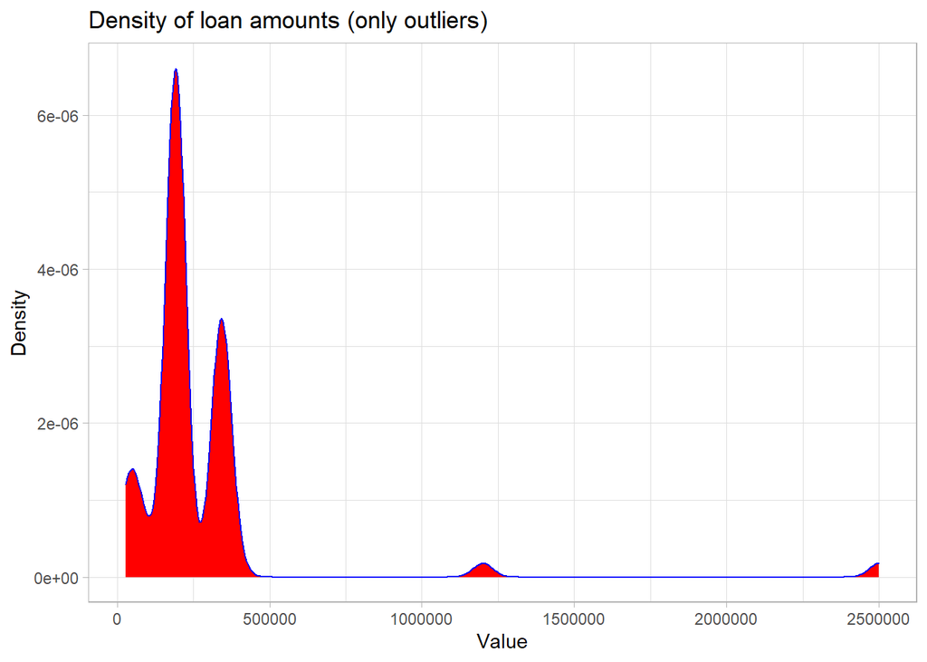

```r
na_process %>% filter(Value > u_outlier) %>% ggplot(aes(Value)) + geom_density(fill = "red", col = "blue") +
  xlab("Value") + ylab("Density") + xlim(28500, 2500000) + ggtitle("Density of loan amounts (only outliers)")
```

Examining correlations among the features

```r
# Examining the correlations among the features
na_process[,-9] %>% cor()
```

```
##                     CustomerId        Value   ProductId ThirdPartyId
## CustomerId         1.000000000 -0.095142691 -0.12328501  0.015978151
## Value             -0.095142691  1.000000000  0.52435115  0.005533551
## ProductId         -0.123285011  0.524351147  1.00000000 -0.025938548
## ThirdPartyId       0.015978151  0.005533551 -0.02593855  1.000000000
## BatchId           -0.005094575  0.118447127  0.15655375  0.030661610
## InvestorId        -0.176969295  0.459887620  0.68537877 -0.053660620
## LoanId             0.043464399 -0.054179854 -0.04755652 -0.022455585
## LoanApplicationId  0.006185429 -0.018045087  0.01209457  0.040954659
## IssueDay          -0.024751232 -0.090660129 -0.04194860 -0.007665210
## IssueMonth         0.074027868 -0.149547869 -0.18299166  0.014542798
## IssueYear         -0.094024616  0.175852754  0.20315716 -0.013527570
## TransactionDay    -0.024614651 -0.090642481 -0.04194337 -0.007784375
## TransactionMonth   0.074027868 -0.149547869 -0.18299166  0.014542798
## TransactionYear   -0.094024616  0.175852754  0.20315716 -0.013527570
##                        BatchId  InvestorId      LoanId LoanApplicationId
## CustomerId        -0.005094575 -0.17696930  0.04346440       0.006185429
## Value              0.118447127  0.45988762 -0.05417985      -0.018045087
## ProductId          0.156553749  0.68537877 -0.04755652       0.012094570
## ThirdPartyId       0.030661610 -0.05366062 -0.02245558       0.040954659
## BatchId            1.000000000  0.12960337 -0.03272072      -0.073642451
## InvestorId         0.129603371  1.00000000 -0.04935021       0.002204900
## LoanId            -0.032720716 -0.04935021  1.00000000       0.036714183
## LoanApplicationId -0.073642451  0.00220490  0.03671418       1.000000000
## IssueDay          -0.021318648 -0.05506112  0.04288045       0.030909479
## IssueMonth        -0.023540831 -0.15591472  0.04199752      -0.039734278
## IssueYear          0.024537049  0.17204789 -0.04638695       0.036848987
## TransactionDay    -0.021432664 -0.05518648  0.04280115       0.030932457
## TransactionMonth  -0.023540831 -0.15591472  0.04199752      -0.039734278
## TransactionYear    0.024537049  0.17204789 -0.04638695       0.036848987
##                      IssueDay  IssueMonth   IssueYear TransactionDay
## CustomerId        -0.02475123  0.07402787 -0.09402462   -0.024614651
## Value             -0.09066013 -0.14954787  0.17585275   -0.090642481
## ProductId         -0.04194860 -0.18299166  0.20315716   -0.041943370
## ThirdPartyId      -0.00766521  0.01454280 -0.01352757   -0.007784375
## BatchId           -0.02131865 -0.02354083  0.02453705   -0.021432664
## InvestorId        -0.05506112 -0.15591472  0.17204789   -0.055186480
## LoanId             0.04288045  0.04199752 -0.04638695    0.042801154
## LoanApplicationId  0.03090948 -0.03973428  0.03684899    0.030932457
## IssueDay           1.00000000  0.01965154 -0.06947928    0.999995714
## IssueMonth         0.01965154  1.00000000 -0.98697630    0.019560339
## IssueYear         -0.06947928 -0.98697630  1.00000000   -0.069361341
## TransactionDay     0.99999571  0.01956034 -0.06936134    1.000000000
## TransactionMonth   0.01965154  1.00000000 -0.98697630    0.019560339
## TransactionYear   -0.06947928 -0.98697630  1.00000000   -0.069361341
##                   TransactionMonth TransactionYear
## CustomerId              0.07402787     -0.09402462
## Value                  -0.14954787      0.17585275
## ProductId              -0.18299166      0.20315716
## ThirdPartyId            0.01454280     -0.01352757
## BatchId                -0.02354083      0.02453705
## InvestorId             -0.15591472      0.17204789
## LoanId                  0.04199752     -0.04638695
## LoanApplicationId      -0.03973428      0.03684899
## IssueDay                0.01965154     -0.06947928
## IssueMonth              1.00000000     -0.98697630
## IssueYear              -0.98697630      1.00000000
## TransactionDay          0.01956034     -0.06936134
## TransactionMonth        1.00000000     -0.98697630
## TransactionYear        -0.98697630      1.00000000
```

# Pre-processing (test data)

```r
# read in the test data
dir = "C:/Users/Khwezi/Documents/Docu/Zindi challenges/Credit scores/data/"

fn = "Test.csv"

fp = paste0(dir, fn)

test = read.csv(fp, sep = ",")

# Selecting relevant features

naive_test = test %>%
  select(CustomerId, Value, ProductId, ThirdPartyId,
         BatchId, IssuedDateLoan, InvestorId, TransactionStartTime,
         TransactionStatus, LoanId, LoanApplicationId)

# Dealing with the dates
naive_test$IssuedDateLoan = naive_test$IssuedDateLoan %>% as_datetime()

naive_test$TransactionStartTime = naive_test$TransactionStartTime %>%
  as_datetime()

# Extracting issue dates and forming new columns
naive_test$IssueDay = naive_test$IssuedDateLoan %>% day()

naive_test$IssueMonth = naive_test$IssuedDateLoan %>% month()

naive_test$IssueYear = naive_test$IssuedDateLoan %>% year()

#Extracting transaction dates and forming new columns
naive_test$TransactionDay = naive_test$TransactionStartTime %>% day()

naive_test$TransactionMonth = naive_test$TransactionStartTime %>% month()

naive_test$TransactionYear = naive_test$TransactionStartTime %>% year()

# Removing IssueDateLoans and TransactionStartTime
pre_test =  naive_test %>% select(-c(IssuedDateLoan, TransactionStartTime))

# Omit the NAs
na_test = na.omit(pre_test)

# Encoding the customer_ids into numeric values
na_test$CustomerId = str_extract(na_test$CustomerId, "\\d+")

na_test$CustomerId = as.numeric(na_test$CustomerId)

# Encoding product_ids into numeric values
na_test$ProductId = str_extract(na_test$ProductId, "\\d+")
na_test$ProductId = as.numeric(na_test$ProductId)

# Encoding third_party_ids into numeric values
na_test$ThirdPartyId = str_extract(na_test$ThirdPartyId, "\\d+")
na_test$ThirdPartyId = as.numeric(na_test$ThirdPartyId)

# Encoding batch_ids into numeric values
na_test$BatchId = str_extract(na_test$BatchId, "\\d+")
na_test$BatchId = as.numeric(na_test$BatchId)

# Encoding investor_ids into numeric values
na_test$InvestorId = str_extract(na_test$InvestorId, "\\d+")
na_test$InvestorId = as.numeric(na_test$InvestorId)

# Encoding loan_ids into numeric values
na_test$LoanId = str_extract(na_test$LoanId, "\\d+")
na_test$LoanId = as.numeric(na_test$LoanId)

# Encoding loan_application_ids into numeric values
na_test$LoanApplicationId = str_extract(na_test$LoanApplicationId, "\\d+")
na_test$LoanApplicationId = as.numeric(na_test$LoanApplicationId)

na_test = na_test[-c(7,12,15)] # remove transaction status, issue_year, trans_year

scale_test = na_test %>% scale()

scale_test_df = scale_test %>% as.data.frame() # the test data

scale_test_df %>% head()
```

|  | CustomerId | Value | ProductId | ThirdPartyId | BatchId | InvestorId | LoanId | LoanApplicationId | IssueDay | IssueMonth | TransactionDay | TransactionMonth |
| --- | --- | --- | --- | --- | --- | --- | --- | --- | --- | --- | --- | --- |
| 1 | 0.48254907 | -0.004070531 | 0.3207883 | 0.3360969 | -0.2277072 | -0.4712122 | 0.3586005 | 0.03123366 | 1.76723 | -2.343446 | 1.76723 | -2.343446 |
| 2 | -0.09340936 | -0.094243000 | 0.5697117 | -0.6363064 | -0.1310710 | -0.4712122 | -0.1957953 | -1.56664225 | 1.76723 | -2.343446 | 1.76723 | -2.343446 |
| 3 | -0.96164519 | -0.083838484 | 0.3207883 | 0.9253290 | 1.1610919 | -0.4712122 | 0.4442215 | 0.87133223 | 1.76723 | -2.343446 | 1.76723 | -2.343446 |
| 4 | -0.96164519 | -0.097711172 | 0.3207883 | -0.9734971 | -0.3284848 | -0.4712122 | -1.4073319 | -0.37404001 | 1.76723 | -2.343446 | 1.76723 | -2.343446 |
| 5 | -0.96164519 | -0.094243000 | 0.3207883 | -1.1506073 | 1.6125206 | -0.4712122 | -0.6988184 | -1.05793935 | 1.76723 | -2.343446 | 1.76723 | -2.343446 |
| 8 | -0.96164519 | -0.097711172 | 0.3207883 | -1.1863699 | 0.3438265 | -0.4712122 | 1.3047122 | -1.18880897 | 1.76723 | -2.343446 | 1.76723 | -2.343446 |